# Análisis Integrado de Vulnerabilidades en la Industria Global de la Bicicleta

Dinámicas geopolíticas, crisis de insumos elastoméricos (caucho natural) y perspectivas para la República Argentina y Mendoza (2025/2026). Trabajo inspirado en la metodología de la cátedra de Técnicas y Herramientas Modernas.

Allamand, Francisco https://fing.uncuyo.edu.ar (Facultad de Ingeniería – Universidad Nacional de Cuyo)https://fing.uncuyo.edu.ar , Notti Echave, Mateo https://fing.uncuyo.edu.ar (Facultad de Ingeniería – Universidad Nacional de Cuyo)https://fing.uncuyo.edu.ar , Dip, Facundo https://fing.uncuyo.edu.ar (Facultad de Ingeniería – Universidad Nacional de Cuyo)https://fing.uncuyo.edu.ar , Elizalde, Pedro https://fing.uncuyo.edu.ar (Facultad de Ingeniería – Universidad Nacional de Cuyo)https://fing.uncuyo.edu.ar  
2026-06-02

## Resumen

Este informe analiza las vulnerabilidades estructurales de la industria global de la bicicleta —rubro modelado en la simulación de eventos discretos del Módulo 3— articulando tres planos: la dinámica del mercado mundial, las barreras comerciales y logísticas, y la dependencia de un insumo agrícola estratégico, el caucho natural. El análisis se complementa con la situación de la República Argentina y el potencial de la provincia de Mendoza. Los resultados muestran un sector en crecimiento sostenido pero altamente expuesto a riesgos sistémicos.

# Introducción

El diseño de sistemas industriales modernos exige comprender no solo la dinámica interna de una planta —como la modelada en SIMUL8 para una fábrica de bicicletas— sino también el contexto global que condiciona la disponibilidad y el costo de los insumos. La bicicleta, lejos de ser un producto simple, integra una cadena de valor internacional intensiva en componentes (cuadros de aluminio, transmisiones, baterías para e-bikes y cubiertas de caucho) cuya logística atraviesa los principales puntos críticos del comercio marítimo mundial.

El mercado global de la bicicleta se valuó en torno a los USD 81,8 mil millones en 2025, con estimaciones que oscilan entre USD 71 y 127 mil millones según la consultora, y un volumen aproximado de 108 millones de unidades anuales (Expert Market Research, 2025; Global Market Insights, 2026). Asia-Pacífico lidera la producción y el consumo (Grand View Research, 2025).

# Dimensión Global

## Estructura del mercado y del comercio internacional

La producción mundial está fuertemente concentrada: China explica cerca del 50 % de la producción global, superando a Brasil —segundo productor— por un orden de magnitud, mientras Indonesia aporta alrededor del 4,7 % (IndexBox, 2026). En valor, China, Taiwán y los Países Bajos concentran la mitad de las exportaciones mundiales, y Estados Unidos, Alemania y los Países Bajos cerca de un tercio de las importaciones (IndexBox, 2026).

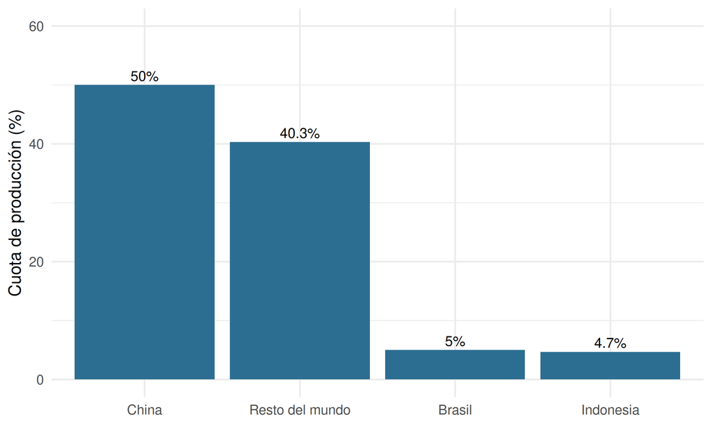

Figure 1: Cuota estimada de producción mundial de bicicletas por país (2025). Fuente: elaboración propia sobre datos de IndexBox (2026).

```r
df1 <- viz$figura_1_produccion_global_por_pais$datos
df1 <- df1[order(-df1$cuota_porcentaje), ]
df1$pais <- factor(df1$pais, levels = df1$pais)

ggplot(df1, aes(x = pais, y = cuota_porcentaje)) +
  geom_col(fill = col_acento) +
  geom_text(aes(label = paste0(cuota_porcentaje, "%")), vjust = -0.4, size = 3.5) +
  labs(x = NULL, y = "Cuota de producción (%)") +
  ylim(0, 60) +
  theme_minimal(base_size = 12)
```

## Barreras comerciales y disrupciones logísticas

El comercio de bicicletas está atravesado por tensiones geopolíticas. La Comisión Europea extendió en enero de 2025, por cinco años adicionales, los derechos antidumping (9,9 %–70,1 %) y compensatorios (3,9 %–17,2 %) sobre las e-bikes chinas, protegiendo unos 12.000 empleos directos en la Unión (European Commission, 2025). Estados Unidos, por su parte, aplica un arancel del 25 % a las e-bikes y partes de origen chino.

A la barrera arancelaria se suma la **fragilidad de los corredores marítimos**. Cerca del 30 % del comercio mundial de contenedores transitaba normalmente por el Canal de Suez; los ataques en el estrecho de Bab al-Mandab (Mar Rojo) desde fines de 2023 provocaron una caída del 90 % del tráfico de contenedores por Suez en 2024 y obligaron a desviar buques por el Cabo de Buena Esperanza, sumando 10 a 15 días de tránsito (United Nations Conference on Trade and Development, 2024). Los fletes spot Asia-Europa llegaron a quintuplicarse, con picos de USD 8.000 a 10.000 por contenedor (J.P. Morgan, 2024). La tensión recurrente en el estrecho de Ormuz refuerza este riesgo por la vía del precio del crudo.

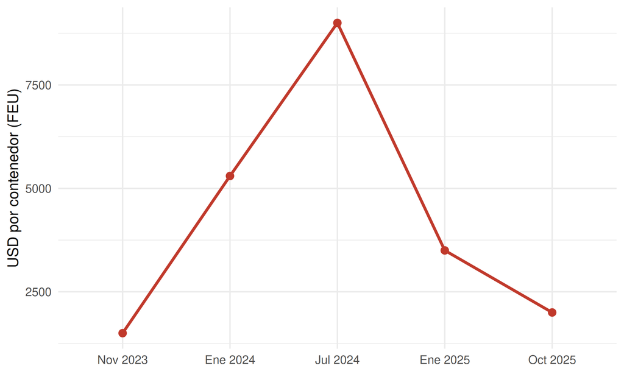

Figure 2: Evolución del flete spot Asia–Europa por contenedor (USD/FEU, valores ilustrativos). Fuente: elaboración propia sobre UNCTAD (2024) y datos de mercado.

```r
df2 <- viz$figura_2_fletes_maritimos$datos
df2$periodo <- factor(df2$periodo, levels = df2$periodo)

ggplot(df2, aes(x = periodo, y = usd_feu, group = 1)) +
  geom_line(color = col_alerta, linewidth = 1.1) +
  geom_point(color = col_alerta, size = 2.5) +
  labs(x = NULL, y = "USD por contenedor (FEU)") +
  theme_minimal(base_size = 12)
```

```r
tab2 <- viz$tabla_2_barreras_comerciales$filas
kable(tab2, col.names = c("Barrera / disrupción", "Valor"),
      caption = viz$tabla_2_barreras_comerciales$titulo)
```

Table 1: Barreras comerciales y disrupciones logisticas (2024-2026)

| Barrera / disrupción | Valor |
| --- | --- |
| Antidumping UE a e-bikes chinas (%) | 9.9 - 70.1 |
| Derecho compensatorio UE (%) | 3.9 - 17.2 |
| Arancel EE.UU. a e-bikes/partes chinas (%) | 25 |
| Caida trafico contenedores via Suez 2024 (%) | 90 |
| Pico flete Asia-Europa 2024 (USD/FEU) | 8.000 - 10.000 |

## Crisis fitosanitaria del caucho natural

Las cubiertas y cámaras de bicicleta dependen del caucho natural extraído de *Hevea brasiliensis*. La oferta mundial registró en 2025 su quinto año consecutivo de déficit, con un faltante anual estimado de 600.000 a 800.000 toneladas que podría extenderse hasta 2028, mientras los precios tocaron máximos de 13 años a fines de 2024 (Tang & Jadhav, 2025). La producción de Tailandia, principal productor, cayó hasta un 10 % en 2024 por factores climáticos y la enfermedad de caída de hojas (Everstream Analytics, 2024).

A este cuadro coyuntural se suma un riesgo estructural mayor: la producción se apoya en monocultivos clonales genéticamente homogéneos en el sudeste asiático, altamente vulnerables a una eventual introducción del *Microcyclus ulei*, hongo causante del Mal Sudamericano de las Hojas (SALB). Un brote de esta magnitud comprometería de forma directa el costo y la disponibilidad de cubiertas, un insumo crítico del producto terminado.

# Dimensión Local: República Argentina

El mercado argentino depende fuertemente de la producción nacional: solo el 10 % de las bicicletas comercializadas son importadas, y el contenido de componentes nacionales en la gama baja ronda el 30 % (Interbike, 2025). Pese a ello, Argentina es el segundo país con bicicletas más caras en una comparativa de nueve economías de PBI per cápita medio-alto (Ámbito Financiero, 2024).

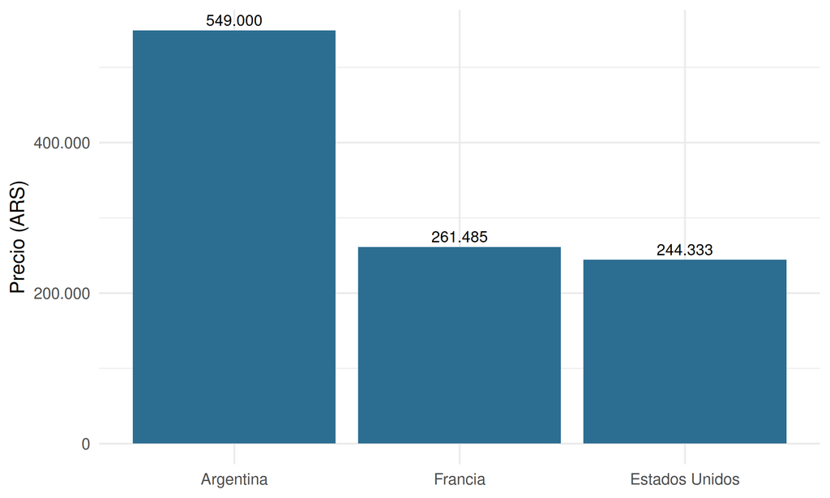

Figure 3: Precio de una Mountain Bike rodado 29 por país, en pesos argentinos (2024). Fuente: elaboración propia sobre Ámbito (2024).

```r
df3 <- viz$figura_3_precio_mtb_comparado$datos
df3 <- df3[order(-df3$precio_ars), ]
df3$pais <- factor(df3$pais, levels = df3$pais)

ggplot(df3, aes(x = pais, y = precio_ars)) +
  geom_col(fill = col_acento) +
  geom_text(aes(label = scales::comma(precio_ars, big.mark = ".")),
            vjust = -0.4, size = 3.3) +
  labs(x = NULL, y = "Precio (ARS)") +
  scale_y_continuous(labels = function(x) format(x, big.mark = ".", scientific = FALSE)) +
  theme_minimal(base_size = 12)
```

```r
tab3 <- viz$tabla_3_indicadores_argentina$filas
kable(tab3, col.names = c("Indicador", "Valor"),
      caption = viz$tabla_3_indicadores_argentina$titulo)
```

Table 2: Indicadores de la industria de la bicicleta en Argentina (2024)

| Indicador | Valor |
| --- | --- |
| Bicicletas importadas sobre total (%) | 10 |
| Contenido nacional en gama baja (%) | ~30 |
| Caida de ventas vs 2023 (%) | 30 |
| Posicion en precio (9 paises) | 2do mas caro |

## Potencial de la industria en Mendoza

Mendoza presenta ejes de oportunidad cualitativos que conviene profundizar con datos provinciales propios: el cicloturismo enoturístico en Luján de Cuyo y Maipú (circuitos *bike & wine*), la expansión de ciclovías y movilidad urbana sustentable en el Gran Mendoza, y el desarrollo de bicipartes con valor agregado local. Esta sección se plantea de forma cualitativa para evitar cifras no verificadas y queda abierta a un relevamiento específico.

# Conclusiones

La industria de la bicicleta combina un crecimiento estructural sostenido —impulsado por la movilidad sustentable y las e-bikes— con una elevada concentración productiva en China y una fuerte exposición a riesgos sistémicos: barreras comerciales, fragilidad logística en los *chokepoints* marítimos y dependencia de un insumo agrícola estratégico sujeto a riesgo fitosanitario. El modelo de eventos discretos del Módulo 3 gana realismo si incorpora el caucho de las cubiertas como insumo crítico de costo volátil y si parametriza el costo de importación de componentes en función de la volatilidad del flete marítimo. Para Argentina y Mendoza, el nuevo marco desregulatorio abre simultáneamente un riesgo (competencia importada) y una oportunidad (cicloturismo, movilidad urbana y bicipartes locales).

# Referencias

Ámbito Financiero. (2024). *Régimen antidumping: El gobierno elimina trabas burocráticas para la importación de bicicletas*. https://www.ambito.com/.

European Commission. (2025). *Commission implementing regulation (EU) 2025/120: Definitive anti-dumping duty on imports of electric bicycles originating in the people’s republic of china*. European Union; https://eur-lex.europa.eu/.

Everstream Analytics. (2024). *Natural rubber shortages intensify*. https://www.everstream.ai/risk-centers/natural-rubber-shortages-intensify/.

Expert Market Research. (2025). *Bicycle market size and share, YoY industry growth by 2035*. https://www.expertmarketresearch.com/reports/bicycle-market.

Global Market Insights. (2026). *Bicycle market size, share, trends: Industry report 2026–2035*. https://www.gminsights.com/industry-analysis/bicycle-market.

Grand View Research. (2025). *Bicycle market size, share & trends: Industry report, 2033*. https://www.grandviewresearch.com/industry-analysis/bicycle-market.

IndexBox. (2026). *Global bicycle market report 2025: Prices, size, forecast, and companies*. https://www.indexbox.io/.

Interbike. (2025). *Estadísticas de bicicletas en argentina*. https://interbike.com.ar/estadisticas-bicicletas-argentina/.

J.P. Morgan. (2024). *The impacts of the red sea shipping crisis*. https://www.jpmorgan.com/insights/global-research/supply-chain/red-sea-shipping.

Tang, A., & Jadhav, R. (2025). *Global rubber shortfall looms in 2025 on stagnant output, association says*. Reuters. https://finance.yahoo.com/news/global-rubber-shortfall-looms-2025-052410800.html.

United Nations Conference on Trade and Development. (2024). *Unprecedented shipping disruptions raise risk to global trade*. UNCTAD; https://unctad.org/news/unprecedented-shipping-disruptions-raise-risk-global-trade-unctad-warns.